# Análisis de competitividad turística de Castilla y León basado en datos abiertos

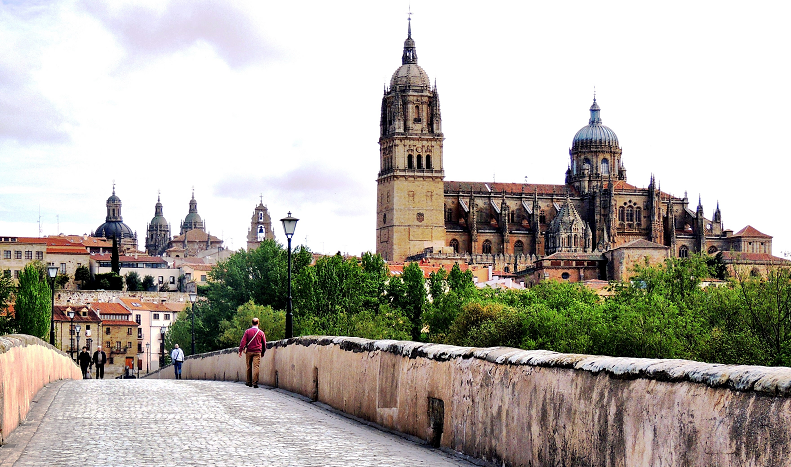

Fuente: imagen de pxhere.com autor: José Luis Cernada Iglesias

## OBJETIVOS y ALCANCE

El presente trabajo realiza un **análisis de competitividad turística de Castilla y León** basado en análisis de datos, concretamente en datos de fuentes abiertas. Así mismo, el trabajo pretende **valorar el potencial de los datos abiertos** como fuente de información en el análisis de un sector de actividad, en este caso el turismo y **el potencial del uso de la Inteligencia Artificial Generativa** en la realización de estos **análisis de datos**.

Se han utilizado una **amplia variedad de fuentes abiertas**:

- 6 fuentes de datos del **[Portal de datos abiertos de la Junta de Castilla y León](https://datosabiertos.jcyl.es/web/es/datos-abiertos-castilla-leon.html)**
- 6 fuentes de datos del **[Instituto Nacional de Estadística](https://www.ine.es/)**
- 1 fuente de datos de **[Segittur](https://www.segittur.es/)**

El análisis se ha desarrollado con el **lenguaje Python los scripts y los ficheros empleados están disponibles** en este [repositorio github](https://github.com/analisisturismoCyL/analisis_turismo_CyL.git). Se han utilizado en el desarrollo:

- Paquetes de **tratamiento y visualización de datos**
- Paquetes de **Machine Learning**
- Llamadas a **[ChatGPT](https://chat.openai.com/)**

Se trabaja con una serie histórica que finaliza en 2022 para trabajar con años cerrados. Los scripts generados están preparados para ser utilizados con datos actualizados de años posteriores. En el desarrollo del trabajo se realizan llamadas a **ChatGPT** para valorar la utilidad del uso de Inteligencia Artificial Generativa en el análisis de datos, encontrándose resultados interesantes.

El resultado de los análisis **se publica en formato HTML** en esta web y se puede **consultar navegando en los tres apartados de la sección de RESULTADOS**. Los análisis se han realizado **paso a paso y se explica el trabajo realizado con los datos para llegar a las conclusiones finales**.

Nos parece importante señalar que aunque el resultado publicado sea una web con el resultado de los análisis, no consideramos que el producto final sea una web en sí mismo, sino que **el producto final y el valor añadido está en el análisis de datos realizado en base a open data y apoyado en IA generativa**. Cabe señalar que los HTML generados contienen textos explicativos, tablas grandes y gráficos detallados y están diseñadas sólo para navegadores de escritorio, no para dispositivos móviles, de tal forma que **recomendamos que sean visualizados desde el navegador de un ordenador**.

Consideramos en base a los resultados obtenidos que **los datos abiertos son una fuente de información con un gran potencial para realizar análisis de datos** o para complementar información de fuentes privadas. Así mismo, **la inteligencia artificial generativa es de gran utilidad en la realización de estos análisis**.

Es un estudio realizado por **[Datademy](https://www.datademy.es)**

## RESULTADOS

### 1. Comparativa Castilla y León con resto comunidades España

### 2. Análisis actividad turística Castilla y León

### 3. Factores competitividad turística

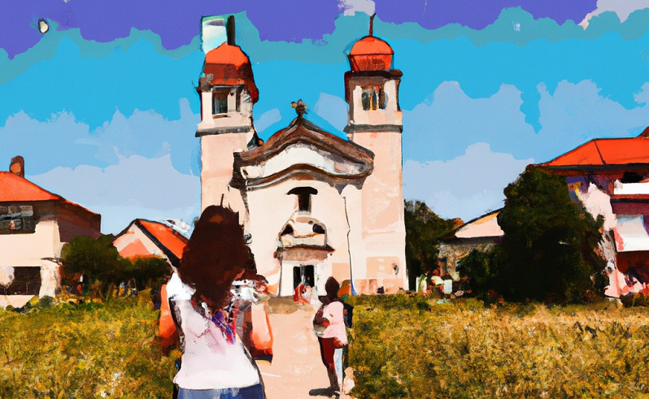

Fuente: imagen generada por Inteligencia Artificial [DALL-E](https://openai.com/dall-e-2) se le solicita una pintura en acuarela de turistas en entorno rural en el que haya iglesias